# Assignment 2

December 03, 2020

## Question 1: Is there disproportionate education attainment by race in Santa Clara County?

To do an equity analysis of educational attainment by race, we first have to import Census data using the functions below. I picked Santa Clara County (code:085) and used the 1 year Census variable B15002 “Sex by Educational Attainment”. This dataset gives me the ability to group the totals by race, sex, and educational level so that I can narrow it down to the individual level.

```r
acs_vars_2019_1yr <-
  listCensusMetadata(
    name = "2019/acs/acs1",
    type = "variables"
  )

census_race_labels <-
  c(
    "White Alone",
    "Black or African American",
    "American Indian and Alaska Native Alone",
    "Asian Alone",
    "Native Hawaiian and Other Pacific Islander Alone)",
    "Some Other Race Alone",
    "Two or More Races"
  )

sc_education_race <-
  1:7 %>%
  map_dfr(function(x){
    getCensus(
      name = "acs/acs1",
      vintage = 2019,
      region = "county:085",
      regionin = "state:06",
      vars = paste0("group(B15002",LETTERS[x],")")
    ) %>%
      select(!c(GEO_ID,state,NAME) & !ends_with(c("EA","MA","M"))) %>%
      pivot_longer(
        ends_with("E"),
        names_to = "variable",
        values_to = "estimate"
      ) %>%
      left_join(
        acs_vars_2019_1yr %>%
          select(name, label),
        by = c("variable" = "name")
      ) %>%
      select(-variable) %>%
      separate(
        label,
        into = c(NA,NA,"sex","education level"),
        sep = "!!"
      ) %>%
      filter(!is.na(`education level`)) %>%
      mutate(race = census_race_labels[x]) %>%
      filter(!is.na(estimate))
  })
```

To make the analysis table, I also included a total population section (shown below) so that we can see how each race compares with all the different educational levels added up. Both the stacked plot and the filled plot are shown below.

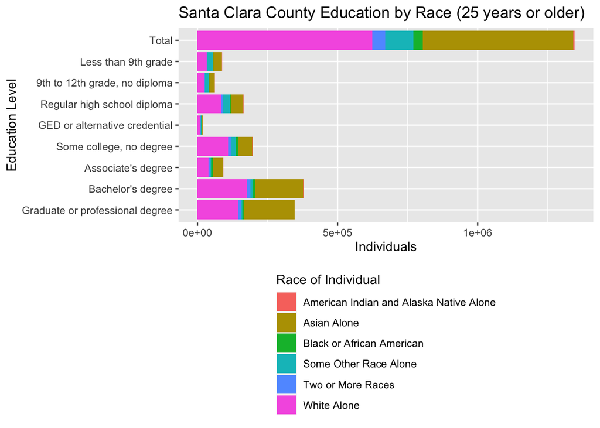

```r
sc_race_total <-
  sc_education_race %>%
  group_by(race) %>%
  summarize(estimate = sum(estimate)) %>%
  mutate(`education level` = "Total")

sc_education_race %>%
  group_by(`education level`, race) %>%
  summarize(estimate = sum(estimate)) %>%
  rbind(sc_race_total) %>%
  ggplot() +
  geom_bar(
    aes(
      x = `education level` %>% factor(levels = rev(c("Total", sc_education_race$`education level`[1:8]))),
      y = estimate,
      fill = race
    ),
    stat = "identity",
    position = "stack"
  ) +
  labs(
    x = "Education Level",
    y = "Individuals",
    title = "Santa Clara County Education by Race (25 years or older)",
    fill = "Race of Individual"
  ) +
  coord_flip() +
  theme(
    legend.position = "bottom",
    legend.direction = "vertical"
  )
```

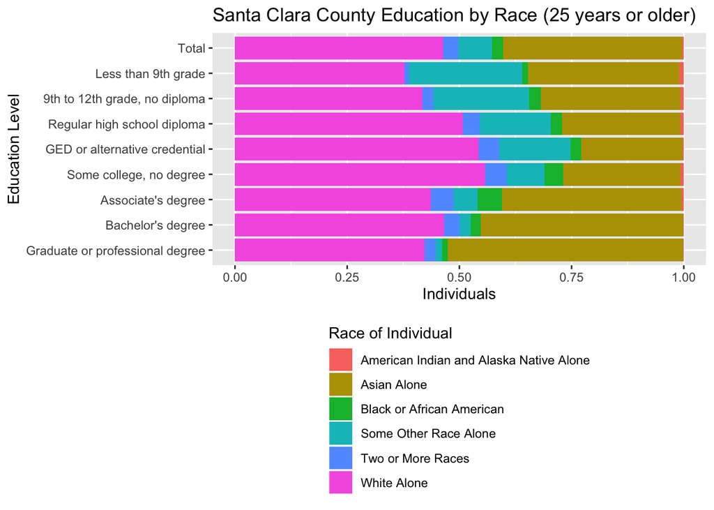

```r
sc_education_race %>%
  group_by(`education level`, race) %>%
  summarize(estimate = sum(estimate)) %>%
  rbind(sc_race_total) %>%
  ggplot() +
  geom_bar(
    aes(
      x = `education level` %>% factor(levels = rev(c("Total", sc_education_race$`education level`[1:8]))),
      y = estimate,
      fill = race
    ),
    stat = "identity",
    position = "fill"
  ) +
  labs(
    x = "Education Level",
    y = "Individuals",
    title = "Santa Clara County Education by Race (25 years or older)",
    fill = "Race of Individual"
  ) +
  coord_flip() +
  theme(
    legend.position = "bottom",
    legend.direction = "vertical"
  )
```

## Analysis of data for question 1

To answer the question: Is there disproportionate education attainment by race in the County? Visually from the stacked bar chart, one can see that the distribution of educational attainment is not even across each race. If educational attainment were race-blind, the proportions of race distribution in each education level should be even as though it were a scaled down version of the total population distribution as shown in the top row.

The analysis can also be demonstrated by the calculations done in the chapter textbook. The calculation below shows that 54% of the overall population in the Santa Clara County is non-white.

```r
((sum(sc_race_total$estimate[1:5])/sum(sc_race_total$estimate))*100) %>% round()
```

```
## [1] 54
```

My assumption is that the education levels 1:4 would be grouped as lower level education. The 4th level in the table ends at “GED or some alternative credential”, and is the equivalent of a high school degree. For the general population nowadays, a high school level education level is insufficient and the individual would be considered at a disadvantage or below ‘average’. We can confirm that by a simple calculation as shown below:

```r
((sc_education_race %>%
    filter(`education level` %in% sc_education_race$`education level`[1:4]) %>%
    pull(estimate) %>%
    sum()) /
    (sc_education_race %>%
      pull(estimate) %>%
      sum()) * 100) %>%
    round()
```

```
## [1] 25
```

The calculation above demonstrates that 25% of the total population is likely at a big disadvantage in terms of their education. Now we can calculate what percentage of the population in this lower bracket range is non-White. The calculation below shows that the sub-population of people who are non-White and have less than a higher education equivalent. This tells us that the percentage of people who have low-education is 54% non-White.

```r
((sc_education_race %>%
  filter(`education level` %in% sc_education_race$`education level`[1:4]) %>%
  filter(race != "White Alone") %>%
  pull(estimate) %>%
  sum()) /
  (sc_education_race %>%
    filter(`education level` %in% sc_education_race$`education level`[1:4]) %>%
    pull(estimate) %>%
    sum()) * 100) %>%
  round()
```

```
## [1] 54
```

In an ideal world, there would be no difference between the % of low-education individuals of everyone versus the % of low-education individuals of a certain race. We can calculate the difference between the % of non-White population who have low-education versus the total number. The difference is 1% as shown in the calculation below.

```r
((((sc_education_race %>%
  filter(`education level` %in% sc_education_race$`education level`[1:4]) %>%
  filter(race != "White Alone") %>%
  pull(estimate) %>%
  sum()) /
  (sc_education_race %>%
    filter(`education level` %in% sc_education_race$`education level`[1:4]) %>%
    pull(estimate) %>%
    sum())) / (sum(sc_race_total$estimate[1:5])/sum(sc_race_total$estimate)) - 1) * 100) %>%
  round()
```

```
## [1] 1
```

Upon looking at the data, however, I would say the methodology of just comparing White only to non-White individuals as stated in the textbook is insufficient for this case. We can clearly see based on the table produced (as shown above) that the bars are skewed in different manners. We can take a look at the distribution higher education between the races. The calculation below shows the % of Asians only who have completed a Bachelor’s or higher. 49% of the total degrees (Bachelor’s or higher) are awarded to Asians.

```r
((sc_education_race %>%
  filter(`education level` %in% sc_education_race$`education level`[7:8]) %>%
  filter(race == "Asian Alone") %>%
  pull(estimate) %>%
  sum()) /
  (sc_education_race %>%
    filter(`education level` %in% sc_education_race$`education level`[7:8]) %>%
    pull(estimate) %>%
    sum()) * 100) %>%
  round()
```

```
## [1] 49
```

However, Asians only take up 40% of the entire population in the Santa Clara County (shown in the calculation below). In an ideal community and if education were “race-blind”, we would find no differences between the percentage of Asians who have a Bachelor’s or higher versus the total percentage of Asians. The percentage should be evenly distributed based on the total distribution of races.

```r
((sum(sc_race_total$estimate[2])/sum(sc_race_total$estimate))*100) %>% round()
```

```
## [1] 40
```

As a result, Asian individuals appear 22 percent more likely to be in a higher education tier than we would expect based on the distribution of races in the Santa Clara County.

```r
((((sc_education_race %>%
  filter(`education level` %in% sc_education_race$`education level`[7:8]) %>%
  filter(race == "Asian Alone") %>%
  pull(estimate) %>%
  sum()) /
  (sc_education_race %>%
    filter(`education level` %in% sc_education_race$`education level`[7:8]) %>%
    pull(estimate) %>%
    sum())) / (sum(sc_race_total$estimate[2])/sum(sc_race_total$estimate)) - 1) * 100) %>%
  round()
```

```
## [1] 22
```

If we take a look at another example of “Some Other Race Alone”, we can see that they make up 7% of the population. Therefore, we can expect that 7% of each education tier is made up of “Some Other Race Alone”.

```r
((sum(sc_race_total$estimate[4])/sum(sc_race_total$estimate))*100) %>% round()
```

```
## [1] 7
```

However, the calculation below shows that in the low education tiers of 1:4, “Some Other Race Alone” makes up 19% of the population group.

```r
((sc_education_race %>%
  filter(`education level` %in% sc_education_race$`education level`[1:4]) %>%
  filter(race == "Some Other Race Alone") %>%
  pull(estimate) %>%
  sum()) /
  (sc_education_race %>%
    filter(`education level` %in% sc_education_race$`education level`[1:4]) %>%
    pull(estimate) %>%
    sum()) * 100) %>%
  round()
```

```
## [1] 19
```

In an ideal community and if education were “race-blind”, we would find no differences between the percentage of the low education folk from “Some Other Race Alone” versus the total percentage of their race. The percentage, as stated before, should be evenly distributed based on the total distribution of races. “Some Other Race Alone” individuals appear 159% percent more likely to be in a lower education tier than we would expect based on the distribution of races in the Santa Clara County. This can be clearly demonstrated in the teal colour of the graph shown earlier. We can see that the teal portion is heavily skewed towards the upper half of the graph, indicating a population that is more centered in the lower-education tiers.

```r
((((sc_education_race %>%
  filter(`education level` %in% sc_education_race$`education level`[1:4]) %>%
  filter(race == "Some Other Race Alone") %>%
  pull(estimate) %>%
  sum()) /
  (sc_education_race %>%
    filter(`education level` %in% sc_education_race$`education level`[1:4]) %>%
    pull(estimate) %>%
    sum())) / (sum(sc_race_total$estimate[4])/sum(sc_race_total$estimate)) - 1) * 100) %>%
  round()
```

```
## [1] 159
```

## Question 2: Estimate the number of number and percentage of K-12 students who have no Internet access at home

To estimate the number of households in the Bay Area who do not have access to Internet at home, we have to utilize Public Use Microdata Sample (PUMS). I first loaded the 1-year PUMS microdata. I used this because it was the most recent data available. I used the variables “ACCESS” for “Access to the Internet” as stated in the var_label for the PUMS data, “R18” for "Presence of persons under 18 years in a household. This is under the assumption that all households who have kids younger than 18 years are sending their kids to school. Of course, this is a best case scenario where if there are more than 1 persons under 18 in the household, it would result in a higher number of students who don’t have Internet access at home. There is also the possibility that not everyone who attends K-12 school is 18 or younger. Either way, visualizing the number of households and individuals would be helpful to identify the regions that need Internet coverage.

```r
pums_vars_2018 <-
  pums_variables %>%
  filter(year == 2018, survey == "acs1")

pums_vars_2018_distinct_hh <-
  pums_vars_2018 %>%
  distinct(var_code, var_label, data_type, level) %>%
  filter(level == "housing")

ca_pums <- get_pums(
  variables = c(
    "PUMA",
    "NP",
    "ACCESS",
    "R18"
  ),
  state = "CA",
  year = 2018,
  survey = "acs1",
  recode = T
)
```

I then intersect the pumas data with the regions that correspond with the Bay area, and filter the data so that I multiply the number of households with K-12 students that have no access to Internet with the weight of the household to get the individuals. I summarize the total individuals who have no access to Internet then divide by the total number of individuals to get a percentage.

```r
ca_pumas <-
  pumas("CA", cb = T, progress_bar = F)

bay_pumas <-
  ca_pumas %>%
  st_centroid() %>%
  .[bay_counties, ] %>%
  st_set_geometry(NULL) %>%
  left_join(ca_pumas %>% select(GEOID10)) %>%
  st_as_sf()

bay_pums <-
  ca_pums %>%
  filter(PUMA %in% bay_pumas$PUMACE10)

bay_pums_internet <-
  bay_pums %>%
  filter(!duplicated(SERIALNO)) %>%
  mutate(
    k12nointernet = ifelse(
      (R18_label == "1 or more persons under 18 in household") &
        (ACCESS_label != "Yes, by paying a cell phone company or Internet service provider"),
      PWGTP,
      0
    )
  ) %>%
  group_by(PUMA) %>%
  summarize(
    perc_k12nointernet =
      sum(k12nointernet, na.rm =T)/sum(PWGTP, na.rm = T)*100
  ) %>%
  left_join(
    bay_pumas %>%
      select(PUMACE10),
    by = c("PUMA" = "PUMACE10")
  ) %>%
  st_as_sf()
```

Here is the process of just summing up the total individuals with no Internet.

```r
bay_pums_internettotal <-
  bay_pums %>%
  filter(!duplicated(SERIALNO)) %>%
  mutate(
    k12nointernet = ifelse(
      (R18_label == "1 or more persons under 18 in household") &
        (ACCESS_label != "Yes, by paying a cell phone company or Internet service provider"),
      PWGTP,
      0
    )
  ) %>%
  group_by(PUMA) %>%
  summarize(
    total_k12nointernet =
      sum(k12nointernet, na.rm =T)
  ) %>%
  left_join(
    bay_pumas %>%
      select(PUMACE10),
    by = c("PUMA" = "PUMACE10")
  ) %>%
  st_as_sf()
```

The number of total K-12 students at who lack access to the Internet is 26462.

```r
sum(bay_pums_internettotal$total_k12nointernet)
```

```
## [1] 26462
```

This plot below shows the percentage of Bay Area households who have no access to Internet that also happen to have K-12 students at home. We can see that Alameda county is perhaps the most striking in terms of the visual differences for the % of households who have no access to the Internet. There are 6% of K-12 students who don’t have access to the Internet. It can be pretty crazy to think about because nowadays seemingly everyone has access to some kind of Internet or news. Having no access to the Internet implies that the students are not able to access any kind of remote learning especially during the pandemic, where schools have shut down in person education.

This kind of data can help Internet providers or school districts figure out what they can do to help make learning more accessible.

```r
pums_pal <- colorNumeric(
  palette = "Oranges",
  domain =bay_pums_internet$perc_k12nointernet
)

leaflet() %>%
  addProviderTiles(providers$CartoDB.Positron) %>%
  addPolygons(
    data = bay_pums_internet,
    fillColor = ~pums_pal(perc_k12nointernet),
    color = "white",
    opacity = 0.5,
    fillOpacity = 0.5,
    weight = 1,
    label = ~paste0(
      round(perc_k12nointernet),
      "% K-12 without access to internet"
    ),
    highlightOptions = highlightOptions(
      weight = 2,
      opacity = 1
    )
  ) %>%
  addLegend(
    data = bay_pums_internet,
    pal = pums_pal,
    values = ~perc_k12nointernet,
    title = "% K-12students <br>without Internet<br>access"
  )
```

[interactive chart not shown]

The total number of K-12 individuals who have no access to Internet is shown below. It tells a similar story, where Alameda county has some of the highest amount of households with no access to Internet. However, this graph is a little bit more telling of the actual number because at the southern tip of Marin county, we can see that there are also quite a few individuals without access to Internet. The first graph showed that the % is 0 and we cannot see clearly from the percentages that this is as big of a problem. This map might be a better indicator of the actual problems that Internet providers and schools have to take into account for access to virtual content.

```r
pums_pal <- colorNumeric(
  palette = "Oranges",
  domain =bay_pums_internettotal$total_k12nointernet
)

leaflet() %>%
  addProviderTiles(providers$CartoDB.Positron) %>%
  addPolygons(
    data = bay_pums_internettotal,
    fillColor = ~pums_pal(total_k12nointernet),
    color = "white",
    opacity = 0.5,
    fillOpacity = 0.5,
    weight = 1,
    label = ~paste0(
      round(total_k12nointernet),
      "Total K-12 without access to internet"
    ),
    highlightOptions = highlightOptions(
      weight = 2,
      opacity = 1
    )
  ) %>%
  addLegend(
    data = bay_pums_internettotal,
    pal = pums_pal,
    values = ~total_k12nointernet,
    title = "Total K-12 individuals without<br>access to the Internet"
  )
```

[interactive chart not shown]

## Question 3: Migration Analysis of Santa Clara County

As for educational attainment migration, we first select census data Table B07009: GEOGRAPHICAL MOBILITY IN THE PAST YEAR BY EDUCATIONAL ATTAINMENT FOR CURRENT RESIDENCE IN THE UNITED STATES.

```r
scc_mobility_current_19 <-
  getCensus(
    name = "acs/acs1",
    vintage = 2019,
    region = "county:085",
    regionin = "state:06",
    vars = c("group(B07009)")
  ) %>%
  select(!c(GEO_ID,state,NAME) & !ends_with(c("EA","MA","M"))) %>%
  pivot_longer(
    ends_with("E"),
    names_to = "variable",
    values_to = "estimate"
  ) %>%
  left_join(
    acs_vars_2019_1yr %>%
      select(name, label),
    by = c("variable" = "name")
  ) %>%
  select(-variable) %>%
  separate(
    label,
    into = c(NA,NA,"mobility","elevel"),
    sep = "!!"
  ) %>%
  mutate(
    mobility = ifelse(
      mobility %in% c("Same house 1 year ago:", "Moved within same county:"),
      "Here since last year",
      "Inflow"
    )
  ) %>%
  filter(!is.na(elevel)) %>%
  group_by(mobility, elevel) %>%
  summarize(estimate = sum(estimate))
```

The last few lines of the code block above help us understand that the code’s columns “same house 1 year ago” and “moved within the same county” means that the people counted within these columns are already present in the county and have not come from anywhere. The ifelse statement says that if the people do not satisfy the requirements of “same house 1 year ago” and “moved within the same county”, they are grouped within the Inflow category of this year and would count as the total number of people coming into the county from somewhere else.

For the next step, we have to understand the change of people from last year to this year. Hence, we choose the data table B07409, GEOGRAPHICAL MOBILITY IN THE PAST YEAR BY EDUCATIONAL ATTAINMENT FOR RESIDENCE 1 YEAR AGO IN THE UNITED STATES.

```r
scc_mobility_lastyear_19 <-
  getCensus(
    name = "acs/acs1",
    vintage = 2019,
    region = "county:085",
    regionin = "state:06",
    vars = c("group(B07409)")
  ) %>%
  select(!c(GEO_ID,state,NAME) & !ends_with(c("EA","MA","M"))) %>%
  pivot_longer(
    ends_with("E"),
    names_to = "variable",
    values_to = "estimate"
  ) %>%
  left_join(
    acs_vars_2019_1yr %>%
      select(name, label),
    by = c("variable" = "name")
  ) %>%
  select(-variable) %>%
  separate(
    label,
    into = c(NA,NA,"mobility","elevel"),
    sep = "!!"
  ) %>%
  mutate(
    mobility = ifelse(
      mobility %in% c("Same house:", "Moved within same county:"),
      "Here since last year",
      "Outflow"
    )
  ) %>%
  filter(!is.na(elevel)) %>%
  group_by(mobility, elevel) %>%
  summarize(estimate = sum(estimate))
```

If you look at the end of the code block above, you can see that the false condition of the ifelse statement is named as outflow. This is to differentiate the changes in people from last year to this year.

The code block below tallies up the total people from the previous year so that we have a basis of reference for the total number of people within the county.

```r
scc_mobility_current_18 <-
  getCensus(
    name = "acs/acs1",
    vintage = 2018,
    region = "county:085",
    regionin = "state:06",
    vars = c("group(B07009)")
  ) %>%
  select(!c(GEO_ID,state,NAME) & !ends_with(c("EA","MA","M"))) %>%
  pivot_longer(
    ends_with("E"),
    names_to = "variable",
    values_to = "estimate"
  ) %>%
  left_join(
    acs_vars_2019_1yr %>%
      select(name, label),
    by = c("variable" = "name")
  ) %>%
  select(-variable) %>%
  separate(
    label,
    into = c(NA,NA,"mobility","elevel"),
    sep = "!!"
  ) %>%
  mutate(
    mobility = "Here last year"
  ) %>%
  filter(!is.na(elevel)) %>%
  group_by(mobility, elevel) %>%
  summarize(estimate = sum(estimate))
```

We then bind together the relevant information from both tables and we can visualize the flow of population based on education level in Santa Clara County.

```r
scc_flows_19 <-
  rbind(
    scc_mobility_current_18,
    scc_mobility_lastyear_19 %>%
      filter(mobility == "Outflow"),
    scc_mobility_current_19 %>%
      filter(mobility == "Inflow"),
    scc_mobility_current_19 %>%
      group_by(elevel) %>%
      summarize(estimate = sum(estimate)) %>%
      mutate(mobility = "Here this year")
  ) %>%
  pivot_wider(
    names_from = mobility,
    values_from = estimate
  ) %>%
  mutate(
    `External net` = Inflow - Outflow,
    `Internal net` = `Here this year` - `Here last year` - `External net`,
  ) %>%
  select(
    `Education level` = elevel,
    `Internal net`,
    `External net`,
    `Here last year`,
    `Here this year`,
    Outflow,
    Inflow
  )
```

## Analysis of Question 3

Based on the data, we can see the external net of graduate or professional degree is at 10166. This is pretty high and it means that there is a large influx of people with professional degrees coming into the county of Santa Clara. This can be due to the demand of highly skilled tech jobs or whatnot in the nearby region. Since Silicon Valley is pretty much situated in this area, it makes sense that there is a large number of professional and graduate degrees needed to satisfy these jobs. However, the internal net tells a different story. Internal net (here this year - here last year - external net) means that the total number of people with bachelor’s degree and graduate degrees are actually decreasing. This means that people are generally migrating out to find jobs in other counties. It makes sense then that there is a large influx of professional degrees needed to fulfill the outflow of skilled workers in the region. We can also see that there is a large negative external net for the educational level of some college degree or associate’s degree. To me, this means that the people who have this degree are likely deciding that it is not viable to survive in this county given the high costs of living. It is perhaps hard to find a job, so there is a general trend of people leaving the area.

```r
scc_flows_19_ordered <- scc_flows_19[c(4, 3, 5, 1, 2),]

knitr::kable(scc_flows_19_ordered)
```

| Education level | Internal net | External net | Here last year | Here this year | Outflow | Inflow |
| --- | --- | --- | --- | --- | --- | --- |
| Less than high school graduate | 3780 | -180 | 145290 | 148890 | 4696 | 4516 |
| High school graduate (includes equivalency) | 56 | 1123 | 184686 | 185865 | 6712 | 7835 |
| Some college or associate’s degree | 119 | -3394 | 293946 | 290671 | 11687 | 8293 |
| Bachelor’s degree | -4379 | -236 | 383232 | 378617 | 23263 | 23027 |
| Graduate or professional degree | -6143 | 10166 | 342615 | 346638 | 17414 | 27580 |